Please find below the R code history from your *Wallace* v1.0.6.3 session.

You can reproduce your session results by running this R Markdown file in RStudio.

Each code block is called a “chunk”, and you can run them either one-by-one or all at once by choosing an option in the “Run” menu at the top-right corner of the “Source” pane in RStudio.

For more detailed information see http://rmarkdown.rstudio.com).

### Package installation

Wallace uses the following R packages that must be installed and loaded before starting.

```r
if (!require(librarian)){
  install.packages("librarian")
  library(librarian)
}
shelf(spocc, spThin, dismo, rgeos, ENMeval, dplyr)
```

[output not shown]

Wallace also includes several functions developed to help integrate different packages and some additional functionality. For this reason, it is necessary to load the file `functions.R`, The function `system.file()` finds this script, and `source()` loads it.

```r
source(system.file('shiny/funcs', 'functions.R', package = 'wallace'))
```

## Record of analysis for *Sula sula*.

### Obtain Occurrence Data

The search for occurrences was limited to 100 records. Obtain occurrence records of the selected species from the gbif database.

```r
sp <- "Sula sula"

# query selected database for occurrence records
results <- spocc::occ(query = sp, from = "gbif", limit = 100, has_coords = TRUE)
# retrieve data table from spocc object
results.data <- results[["gbif"]]$data[[formatSpName(sp)]]
# remove rows with duplicate coordinates
occs.dups <- duplicated(results.data[c('longitude', 'latitude')])
occs <- results.data[!occs.dups,]
# make sure latitude and longitude are numeric (sometimes they are characters)
occs$latitude <- as.numeric(occs$latitude)
occs$longitude <- as.numeric(occs$longitude)
# give all records a unique ID
occs$occID <- row.names(occs)
```

### Process Occurrence Data

The following code recreates the polygon used to select occurrences to keep in the analysis.

```r
# selCoords <- data.frame(x = c(-137.7221, -121.6379, -123.1321, -118.298, -96.0614, -89.5574, -111.1788, -132.7123, -137.7221), y = c(61.228, 39.4362, 35.2456, 31.7282, 32.6209, 41.9023, 57.5158, 61.939, 61.228))
# selPoly <- sp::SpatialPolygons(list(sp::Polygons(list(sp::Polygon(selCoords)), ID=1)))
# plot(selPoly)

selPoly_buf_dd <- 0.5

occs.xy <- occs[c('longitude', 'latitude')]
sp::coordinates(occs.xy) <- ~ longitude + latitude
selPoly <- mcp(occs.xy)
selPoly <- rgeos::gBuffer(selPoly, width = selPoly_buf_dd)

occs.xy <- occs[c('longitude', 'latitude')]
sp::coordinates(occs.xy) <- ~ longitude + latitude
intersect <- sp::over(occs.xy, selPoly)
intersect.rowNums <- as.numeric(which(!(is.na(intersect))))
occs <- occs[intersect.rowNums, ]
```

### Obtain Environmental Data

Originally, used WorldClim (http://www.worldclim.org/) bioclimatic dataset at resolution of 10 arcmin.

#### sdmpredictors

- [sdmpredictors quickstart guide](https://cran.r-project.org/web/packages/sdmpredictors/vignettes/quickstart.html)

```r
shelf(DT, here, sdmpredictors) # ?sdmpredictors
```

[output not shown]

```r
dir_data <- here("data")

datasets <- list_datasets(terrestrial = FALSE, marine = TRUE)
layers <- list_layers(datasets)

# TODO: check out MARSPEC layers
lyrs <- layers %>%
  filter(
    dataset_code == "Bio-ORACLE",
    derivation == "mean")
datatable(lyrs)
```

|  | dataset_code | layer_code | name | description | terrestrial | marine | freshwater | cellsize_equalarea | cellsize_lonlat | units | primary_type | primary_spatial_resolution | primary_source | start_year | start_month | start_day | end_year | end_month | end_day | derivation | month | is_surface | version |
| --- | --- | --- | --- | --- | --- | --- | --- | --- | --- | --- | --- | --- | --- | --- | --- | --- | --- | --- | --- | --- | --- | --- | --- |
| 1 | Bio-ORACLE | BO_calcite | Calcite (mean) | Calcite concentration indicates the mean concentration of calcite (CaCO3) in oceans. | False | True | False | 7000 | 0.083333333 | mol/mŸ | Satellite (Aqua-MODIS), seasonal climatologies | '' | Reference: (Feldman &amp; McClain 2010) URL: http://oceancolor.gsfc.nasa.gov/ | 2002 | 1 | 1 | 2009 | 12 | 31 | mean |  | True | 1 |
| 2 | Bio-ORACLE | BO_chlomean | Chlorophyll A (mean) | Chlorophyll A concentration indicates the concentration of photosynthetic pigment chlorophyll A (the most common "green" chlorophyll) in oceans. Please note that in shallow water these values may refl… | False | True | False | 7000 | 0.083333333 | mg/mŸ | Satellite (Aqua-MODIS), monthly climatologies | '' | Reference: (Feldman &amp; McClain 2010) URL: http://oceancolor.gsfc.nasa.gov/ | 2002 | 1 | 1 | 2009 | 12 | 31 | mean |  | True | 1 |
| 3 | Bio-ORACLE | BO_chlomin | Chlorophyll A (minimum) | Chlorophyll A concentration indicates the concentration of photosynthetic pigment chlorophyll A (the most common "green" chlorophyll) in oceans. Please note that in shallow water these values may refl… | False | True | False | 7000 | 0.083333333 | mg/mŸ | Satellite (Aqua-MODIS), monthly climatologies | '' | Reference: (Feldman &amp; McClain 2010) URL: http://oceancolor.gsfc.nasa.gov/ | 2002 | 1 | 1 | 2009 | 12 | 31 | mean |  | True | 1 |
| 4 | Bio-ORACLE | BO_cloudmean | Cloud fraction (mean) | Cloud fraction indicates how much of the earth is covered by clouds. | False | True | False | 7000 | 0.083333333 | % | Satellite (Terra-MODIS), monthly images | '' | Reference: (NASA 2010) URL: http://neo.sci.gsfc.nasa.gov/Search.html | 2005 | 1 | 1 | 2010 | 12 | 31 | mean |  | True | 1 |
| 5 | Bio-ORACLE | BO_damean | Diffuse attenuation coefficient at 490 nm (mean) | The diffuse attenuation coefficient is an indicator of water clarity. It expresses how deeply visible light in the blue to the green region of the spectrum penetrates in to the water column. | False | True | False | 7000 | 0.083333333 | m^-1 | Satellite (Aqua-MODIS), monthly climatologies | '' | Reference: (Feldman &amp; McClain 2010) URL: http://oceancolor.gsfc.nasa.gov/ | 2002 | 1 | 1 | 2009 | 12 | 31 | mean |  | True | 1 |
| 6 | Bio-ORACLE | BO_parmean | Photosynthetically available radiation (mean) | Photosynthetically Available Radiation (PAR) indicates the quantum energy flux from the Sun (in the spectral range 400-700 nm) reaching the ocean surface. | False | True | False | 7000 | 0.083333333 | Einstein/m_/day | Satellite (SeaWIFS), monthly climatologies | '' | Reference: (Feldman &amp; McClain 2010) URL: http://oceancolor.gsfc.nasa.gov/ | 1997 | 1 | 1 | 2009 | 12 | 31 | mean |  | True | 1 |
| 7 | Bio-ORACLE | BO_sstmean | Sea surface temperature (mean) | Sea surface temperature is the temperature of the water at the ocean surface. This parameter indicates the temperature of the topmost meter of the ocean water column. | False | True | False | 7000 | 0.083333333 | Celsius | Satellite (Aqua-MODIS), monthly climatologies | 5 arcmin (9.2 km) | Reference: (Feldman &amp; McClain 2010) URL: http://oceancolor.gsfc.nasa.gov/ | 2002 | 1 | 1 | 2009 | 12 | 31 | mean |  | True | 1 |
| 8 | Bio-ORACLE | BO_bathymean | Bathymetry (mean) | Average depth of the seafloor | False | True | False | 7000 | 0.083333333 | meters | GEBCO / EMODnet Bathymetry | 30 arcsecond | GEBCO URL: http://gebco.net EMODnet Bathymetry URL: http://www.emodnet-bathymetry.eu/ | 2016 | 3 | 18 | 2016 | 3 | 18 | mean |  | True | 1 |
| 9 | Bio-ORACLE | BO2_icecovermean_ss | Sea ice concentration (mean) | Mean sea ice concentration | False | True | False | 7000 | 0.083333333 | fraction | Model | 0.25 arcdegree | Global Ocean Physics Reanalysis ECMWF ORAP5.0 (1979-2013) URL: http://marine.copernicus.eu/ | 2000 |  |  | 2014 |  |  | mean |  | True | 2 |
| 10 | Bio-ORACLE | BO2_icethickmean_ss | Sea ice thickness (mean) | Mean sea ice thickness | False | True | False | 7000 | 0.083333333 | m | Model | 0.25 arcdegree | Global Ocean Physics Reanalysis ECMWF ORAP5.0 (1979-2013) URL: http://marine.copernicus.eu/ | 2000 |  |  | 2014 |  |  | mean |  | True | 2 |

[output cut: 4 more lines]

```r
# get layers
options(sdmpredictors_datadir= dir_data)
envs <- load_layers(lyrs)

# set cell resolution
envRes <- res(envs)[1] # 0.1666667

# get WorldClim bioclimatic variable rasters
# envs <- raster::getData(name = "worldclim", var = "bio", res = 10, path = dir_data)
# change names rasters variables
# envRes <- 10
# if (envRes == 0.5) {
#   i <- grep('_', names(envs))
#   editNames <- sapply(strsplit(names(envs)[i], '_'), function(x) x[1])
#   names(envs)[i] <- editNames
# }
# i <- grep('bio[0-9]$', names(envs))
# editNames <- paste('bio', sapply(strsplit(names(envs)[i], 'bio'), function(x) x[2]), sep='0')
# names(envs)[i] <- editNames
# subset by those variables selected
# envs <- envs[[c('bio01', 'bio02', 'bio03', 'bio04', 'bio05', 'bio06', 'bio07', 'bio08', 'bio09', 'bio10', 'bio11', 'bio12', 'bio13', 'bio14', 'bio15', 'bio16', 'bio17', 'bio18', 'bio19')]]
```

- [Modeling methods — R Spatial](https://rspatial.org/raster/sdm/6_sdm_methods.html)

```r
shelf(sf)
```

[output not shown]

```r
datatable(occs)
```

|  | name | longitude | latitude | issues | prov | key | scientificName | datasetKey | publishingOrgKey | installationKey | publishingCountry | protocol | lastCrawled | lastParsed | crawlId | hostingOrganizationKey | basisOfRecord | occurrenceStatus | taxonKey | kingdomKey | phylumKey | classKey | orderKey | familyKey | genusKey | speciesKey | acceptedTaxonKey | acceptedScientificName | kingdom | … |
| --- | --- | --- | --- | --- | --- | --- | --- | --- | --- | --- | --- | --- | --- | --- | --- | --- | --- | --- | --- | --- | --- | --- | --- | --- | --- | --- | --- | --- | --- | --- |
| 1 | Sula sula (Linnaeus, 1766) | 102.7 | 10.5 | cucdmis,colmano,inmano | gbif | 3015577634 | Sula sula (Linnaeus, 1766) | b1047888-ae52-4179-9dd5-5448ea342a24 | 1f00d75c-f6fc-4224-a595-975e82d7689c | 85ccfd1a-a837-48d6-9a87-96c99f6fe012 | NL | DWC_ARCHIVE | 2021-01-29T06:04:54.126+00:00 | 2021-01-29T06:11:29.983+00:00 | 110 | 396d5f30-dea9-11db-8ab4-b8a03c50a862 | HUMAN_OBSERVATION | PRESENT | 2480972 | 1 | 44 | 212 | 7192775 | 9351 | 2480966 | 2480972 | 2480972 | Sula sula (Linnaeus, 1766) | Animalia | … |
| 2 | Sula sula (Linnaeus, 1766) | -109.363297 | 22.241633 | cdround,cudc,gass84,colmano,inmano | gbif | 2549999332 | Sula sula (Linnaeus, 1766) | 50c9509d-22c7-4a22-a47d-8c48425ef4a7 | 28eb1a3f-1c15-4a95-931a-4af90ecb574d | 997448a8-f762-11e1-a439-00145eb45e9a | US | DWC_ARCHIVE | 2021-01-30T21:46:57.479+00:00 | 2021-01-30T23:50:20.750+00:00 | 250 | 28eb1a3f-1c15-4a95-931a-4af90ecb574d | HUMAN_OBSERVATION | PRESENT | 2480972 | 1 | 44 | 212 | 7192775 | 9351 | 2480966 | 2480972 | 2480972 | Sula sula (Linnaeus, 1766) | Animalia | … |
| 3 | Sula sula (Linnaeus, 1766) | -159.401262 | 22.227733 | cdround,gass84,colmano,inmano | gbif | 2550046757 | Sula sula (Linnaeus, 1766) | 50c9509d-22c7-4a22-a47d-8c48425ef4a7 | 28eb1a3f-1c15-4a95-931a-4af90ecb574d | 997448a8-f762-11e1-a439-00145eb45e9a | US | DWC_ARCHIVE | 2021-01-30T21:46:57.479+00:00 | 2021-01-30T23:50:20.221+00:00 | 250 | 28eb1a3f-1c15-4a95-931a-4af90ecb574d | HUMAN_OBSERVATION | PRESENT | 2480972 | 1 | 44 | 212 | 7192775 | 9351 | 2480966 | 2480972 | 2480972 | Sula sula (Linnaeus, 1766) | Animalia | … |
| 4 | Sula sula (Linnaeus, 1766) | -109.448655 | 22.289795 | cudc,gass84,colmano,inmano | gbif | 2550049974 | Sula sula (Linnaeus, 1766) | 50c9509d-22c7-4a22-a47d-8c48425ef4a7 | 28eb1a3f-1c15-4a95-931a-4af90ecb574d | 997448a8-f762-11e1-a439-00145eb45e9a | US | DWC_ARCHIVE | 2021-01-30T21:46:57.479+00:00 | 2021-01-30T23:50:21.738+00:00 | 250 | 28eb1a3f-1c15-4a95-931a-4af90ecb574d | HUMAN_OBSERVATION | PRESENT | 2480972 | 1 | 44 | 212 | 7192775 | 9351 | 2480966 | 2480972 | 2480972 | Sula sula (Linnaeus, 1766) | Animalia | … |
| 5 | Sula sula (Linnaeus, 1766) | -159.40196 | 22.231695 | cdround,gass84,colmano,inmano | gbif | 2550134203 | Sula sula (Linnaeus, 1766) | 50c9509d-22c7-4a22-a47d-8c48425ef4a7 | 28eb1a3f-1c15-4a95-931a-4af90ecb574d | 997448a8-f762-11e1-a439-00145eb45e9a | US | DWC_ARCHIVE | 2021-01-30T21:46:57.479+00:00 | 2021-01-30T23:50:21.220+00:00 | 250 | 28eb1a3f-1c15-4a95-931a-4af90ecb574d | HUMAN_OBSERVATION | PRESENT | 2480972 | 1 | 44 | 212 | 7192775 | 9351 | 2480966 | 2480972 | 2480972 | Sula sula (Linnaeus, 1766) | Animalia | … |
| 6 | Sula sula (Linnaeus, 1766) | -159.402181 | 22.230167 | cdround,gass84,colmano,inmano | gbif | 2557775284 | Sula sula (Linnaeus, 1766) | 50c9509d-22c7-4a22-a47d-8c48425ef4a7 | 28eb1a3f-1c15-4a95-931a-4af90ecb574d | 997448a8-f762-11e1-a439-00145eb45e9a | US | DWC_ARCHIVE | 2021-01-30T21:46:57.479+00:00 | 2021-01-30T23:50:20.988+00:00 | 250 | 28eb1a3f-1c15-4a95-931a-4af90ecb574d | HUMAN_OBSERVATION | PRESENT | 2480972 | 1 | 44 | 212 | 7192775 | 9351 | 2480966 | 2480972 | 2480972 | Sula sula (Linnaeus, 1766) | Animalia | … |
| 7 | Sula sula (Linnaeus, 1766) | -159.401294 | 22.227744 | cdround,gass84,colmano,inmano | gbif | 2557782442 | Sula sula (Linnaeus, 1766) | 50c9509d-22c7-4a22-a47d-8c48425ef4a7 | 28eb1a3f-1c15-4a95-931a-4af90ecb574d | 997448a8-f762-11e1-a439-00145eb45e9a | US | DWC_ARCHIVE | 2021-01-30T21:46:57.479+00:00 | 2021-01-30T23:50:15.759+00:00 | 250 | 28eb1a3f-1c15-4a95-931a-4af90ecb574d | HUMAN_OBSERVATION | PRESENT | 2480972 | 1 | 44 | 212 | 7192775 | 9351 | 2480966 | 2480972 | 2480972 | Sula sula (Linnaeus, 1766) | Animalia | … |
| 8 | Sula sula (Linnaeus, 1766) | -159.401875 | 22.231648 | cdround,gass84,colmano,inmano | gbif | 2563637675 | Sula sula (Linnaeus, 1766) | 50c9509d-22c7-4a22-a47d-8c48425ef4a7 | 28eb1a3f-1c15-4a95-931a-4af90ecb574d | 997448a8-f762-11e1-a439-00145eb45e9a | US | DWC_ARCHIVE | 2021-01-30T21:46:57.479+00:00 | 2021-01-30T23:50:23.883+00:00 | 250 | 28eb1a3f-1c15-4a95-931a-4af90ecb574d | HUMAN_OBSERVATION | PRESENT | 2480972 | 1 | 44 | 212 | 7192775 | 9351 | 2480966 | 2480972 | 2480972 | Sula sula (Linnaeus, 1766) | Animalia | … |
| 9 | Sula sula websteri Rothschild, 1898 | -159.401899 | 22.229654 | cdround,gass84,colmano,inmano | gbif | 2573914797 | Sula sula websteri Rothschild, 1898 | 50c9509d-22c7-4a22-a47d-8c48425ef4a7 | 28eb1a3f-1c15-4a95-931a-4af90ecb574d | 997448a8-f762-11e1-a439-00145eb45e9a | US | DWC_ARCHIVE | 2021-01-30T21:46:57.479+00:00 | 2021-01-30T23:50:21.999+00:00 | 250 | 28eb1a3f-1c15-4a95-931a-4af90ecb574d | HUMAN_OBSERVATION | PRESENT | 6066491 | 1 | 44 | 212 | 7192775 | 9351 | 2480966 | 2480972 | 6066491 | Sula sula websteri Rothschild, 1898 | Animalia | … |
| 10 | Sula sula (Linnaeus, 1766) | -159.402075 | 22.2308 | cdround,gass84,colmano,inmano | gbif | 2574229892 | Sula sula (Linnaeus, 1766) | 50c9509d-22c7-4a22-a47d-8c48425ef4a7 | 28eb1a3f-1c15-4a95-931a-4af90ecb574d | 997448a8-f762-11e1-a439-00145eb45e9a | US | DWC_ARCHIVE | 2021-01-30T21:46:57.479+00:00 | 2021-01-30T23:51:59.742+00:00 | 250 | 28eb1a3f-1c15-4a95-931a-4af90ecb574d | HUMAN_OBSERVATION | PRESENT | 2480972 | 1 | 44 | 212 | 7192775 | 9351 | 2480966 | 2480972 | 2480972 | Sula sula (Linnaeus, 1766) | Animalia | … |

[output cut: 68 more lines]

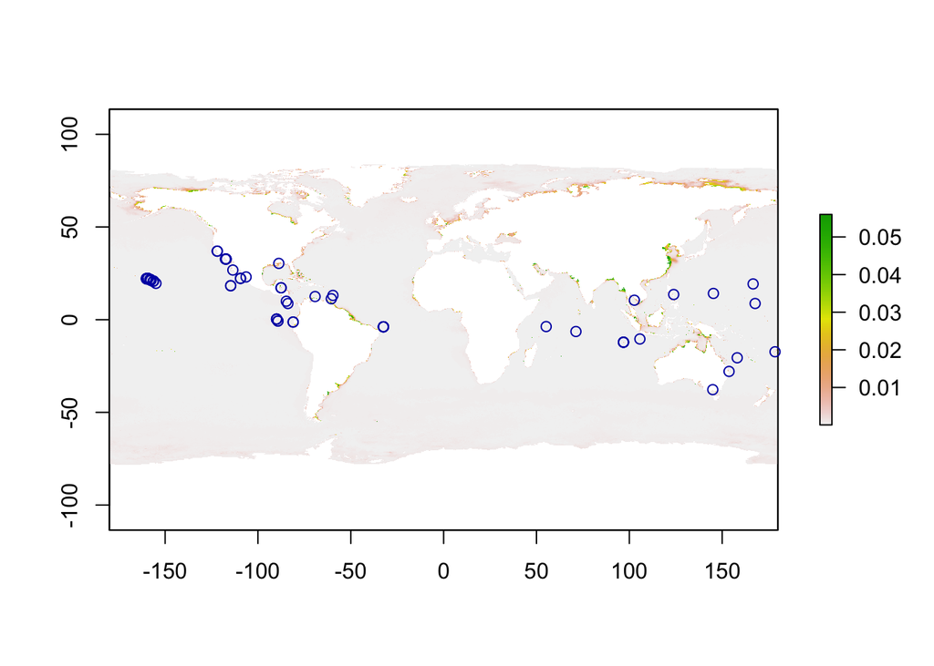

```r
occs_pts <- occs %>%
  st_as_sf(
    coords = c("longitude", "latitude"),
    remove = F,
    crs = 4326) %>%
  mutate(
    presence = T)

occs_bb <- st_bbox(occs_pts)

plot(envs[[1]])
plot(occs_pts["presence"], add = T)
```

```r
# extract environmental values at occ grid cells
locs.vals <- raster::extract(envs[[1]], occs[, c('longitude', 'latitude')])
# remove occs without environmental values
occs <- occs[!is.na(locs.vals), ]  # removed 2
```

### Process Environmental Data

Background selection technique chosen as Minimum Convex Polygon.

```r
occs.xy <- occs[c('longitude', 'latitude')]
sp::coordinates(occs.xy) <- ~ longitude + latitude
bgExt <- mcp(occs.xy)
```

Buffer size of the study extent polygon defined as 0.5 degrees.

```r
bgExt <- rgeos::gBuffer(bgExt, width = 0.5)
```

Mask environmental variables by Minimum Convex Polygon, and take a random sample of background values from the study extent. As the sample is random, your results may be different than those in the session. If there seems to be too much variability in these background samples, try increasing the number from 10,000 to something higher (e.g. 50,000 or 100,000). The better your background sample, the less variability you’ll have between runs.

```r
# crop the environmental rasters by the background extent shape
envsBgCrop <- raster::crop(envs, bgExt)
# mask the background extent shape from the cropped raster
envsBgMsk <- raster::mask(envsBgCrop, bgExt)
# sample random background points
bg.xy <- dismo::randomPoints(envsBgMsk, 10000)
# convert matrix output to data frame
bg.xy <- as.data.frame(bg.xy)
```

### Partition Occurrence Data

Occurrence data is now partitioned for cross-validation, a method that iteratively builds a model on all but one group and evaluates that model on the left-out group.

For example, if the data is partitioned into 3 groups A, B, and C, a model is first built with groups A and B and is evaluated on C. This is repeated by building a model with B and C and evaluating on A, and so on until all combinations are done.

Cross-validation operates under the assumption that the groups are independent of each other, which may or may not be a safe assumption for your dataset. Spatial partitioning is one way to ensure more independence between groups.

```r
occs.xy <- occs[c('longitude', 'latitude')]
group.data <- ENMeval::get.randomkfold(occ=occs.xy, bg.coords=bg.xy, kfolds=5)
```

```r
# pull out the occurrence and background partition group numbers from the list
occs.grp <- group.data[[1]]
bg.grp <- group.data[[2]]
```

### Build and Evaluate Niche Model

You selected the maxent model.

```r
shelf(glue, readr, stringr)
```

[output not shown]

```r
# define the vector of regularization multipliers to test
rms <- seq(1, 2, 1)

# iterate model building over all chosen parameter settings
mx_rds <- here(glue("data/{sp %>% str_replace_all(' ', '_')}.maxent.rds"))

if (!file.exists(mx_rds)){
  e <- ENMeval::ENMevaluate(
    occs.xy, envsBgMsk, bg.coords = bg.xy, RMvalues = rms, fc = c('L', 'LQ'),
    method = 'user', occs.grp, bg.grp, clamp = TRUE, algorithm = "maxent.jar")
  write_rds(e, mx_rds)
} else {
  e <- read_rds(mx_rds)
}

# unpack the results data frame, the list of models, and the RasterStack of raw predictions
evalTbl         <- e@results
evalMods        <- e@models
names(evalMods) <- e@results$settings
evalPreds       <- e@predictions
```

```
## This is MaxEnt version 3.4.1
```

[output not shown]

[output not shown]

[output not shown]

[output not shown]

[output not shown]

[output not shown]

[output not shown]

[output not shown]

[output not shown]

[output not shown]

[output not shown]

[output not shown]

[output not shown]

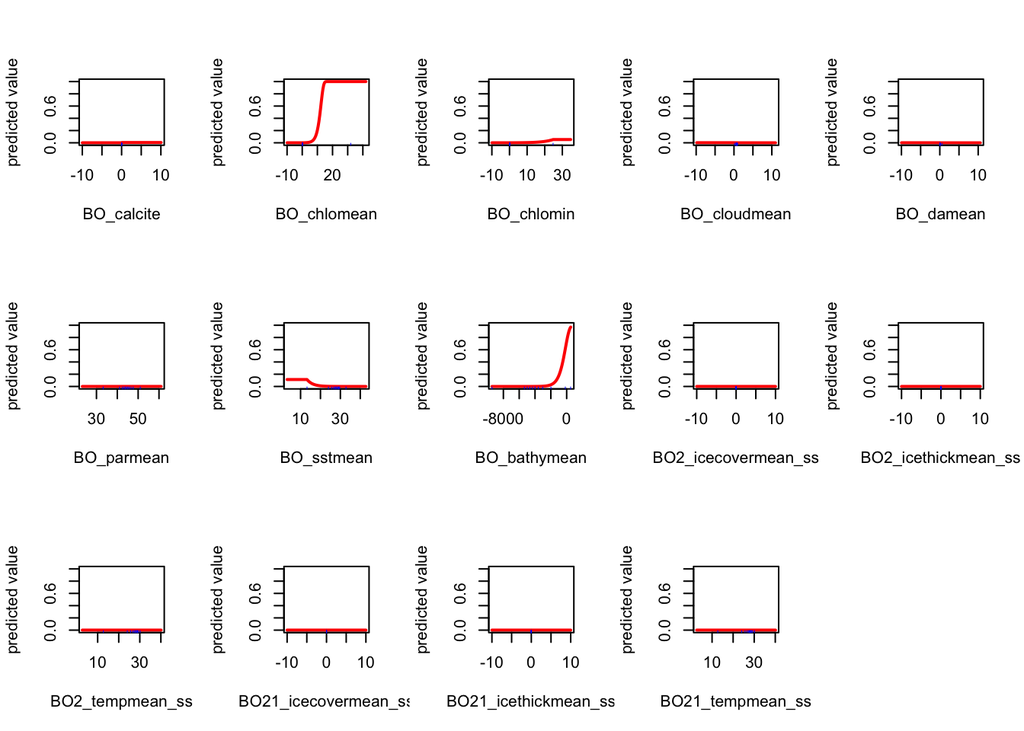

```r
# view response curves for environmental variables with non-zero coefficients
# dismo::response(evalMods[["L_1"]], var = c('bio01', 'bio02', 'bio03', 'bio04', 'bio05', 'bio07', 'bio08', 'bio09', 'bio12', 'bio13', 'bio14', 'bio15', 'bio16', 'bio17', 'bio18', 'bio19'))
dismo::response(evalMods[["L_1"]], var = names(envs))
```

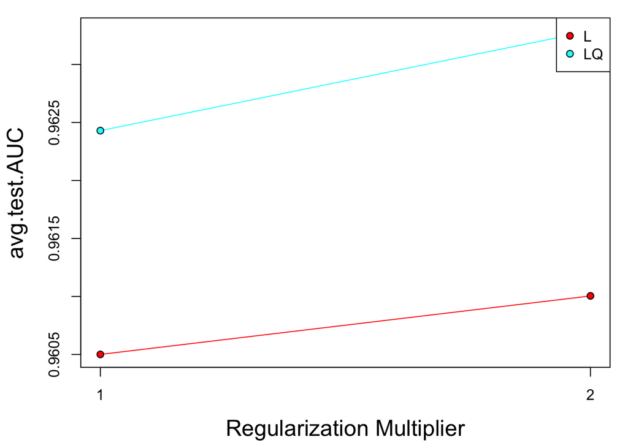

```r
# view ENMeval results
ENMeval::eval.plot(evalTbl, value = "avg.test.AUC")
```

```r
# Select your model from the models list
mod <- evalMods[["L_1"]]
```

```r
# generate raw prediction
pred <- evalPreds[["L_1"]]
```

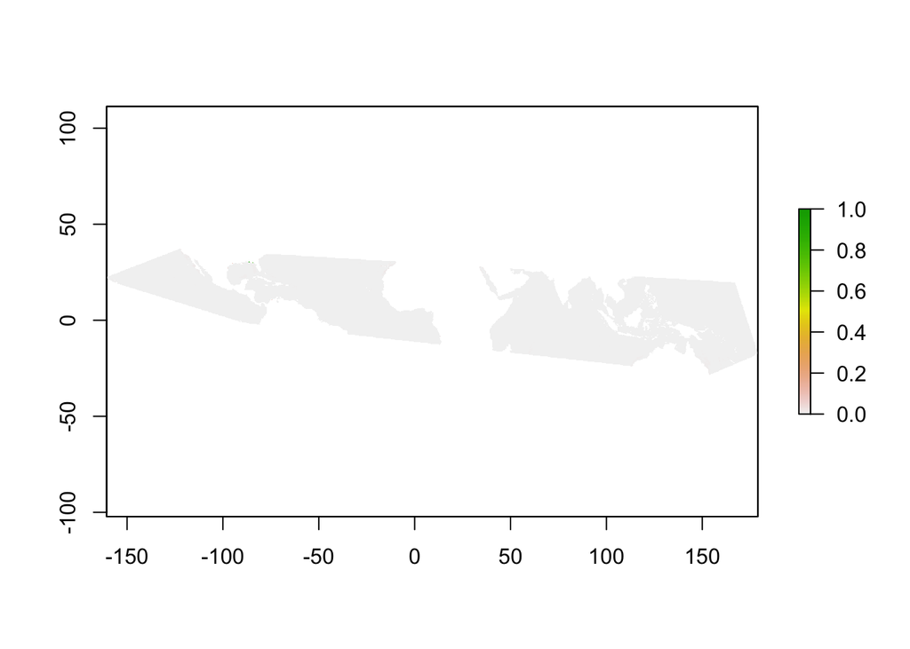

```r
# plot the model prediction
plot(pred)
```

```r
pred_v <- values(pred)
# TODO: use threshold(evaluate(p=p, a=a)) based on test data predictions
table(pred_v > 0.01)
```

```
##
##   FALSE    TRUE
## 1289525     697
```

```r
table(pred_v > 0.1)
```

```
##
##   FALSE    TRUE
## 1290175      47
```

```r
table(pred_v > 0.5)
```

```
##
##   FALSE    TRUE
## 1290214       8
```

TODO: - limit background environmental sampling to similar depths or distance from shore - speed up by caching results, a la mx_rds - update Shiny app to use sdmpredictors